# 6.20 slides slides

## Gene Expression Data

- Introduction to gene expression
- Introduction to microarrays and data collection
- Download the data
- Visualize the data

## Gene Expression

### Gene Basics

- Every cell in the body contains the same 46 chromosomes which are made up of DNA.
- Short sections of DNA are called genes and they provide instructions for cells to make proteins.
- Proteins govern most cellular functions.
- Depending on the type of cell and the gene, the process of gene expression happens at varying levels, from none to a lot.
  - The amount a gene is expressed is directly related to the amount of that protein in the cell.

### From Gene to Protein

1. Transcription
   - The DNA in a gene gets copied into messenger RNA (mRNA).
   - During this process, introns (non-coding portions of the DNA) are removed and the remaining exons are joined together.
2. Translation
   - The information in mRNA is used to produce an amino acid chain which then folds into a specific protein.
   - That resulting protein then performs a specific function in the cell.

### Regulating Gene Expression

- A cell has control over the timing and the amount that its genes are expressed.
- The regulation of gene expression for certain genes can be altered in cancerous cells, causing those genes to be over- or under-expressed.
- Because of this relationship between gene expression and cancer, we want to see if differentially expressed genes are informative of drug efficacy.

## Collecting Gene Expression Data

We are interested in the amount in which different types of proteins are present in each cell. To estimate this, we use gene expression as a proxy and quantify how much each of the thousands of genes in a cell are expressed.

### The Process

1. mRNA is collected from the cells of interest (for example, from a GDSC cell line).
2. The mRNA is converted into complementary DNA (cDNA) that has a fluorescent tag.
3. The cDNA is placed on a microarray.
   - A microarray is a plate with thousands of tiny spots in known locations, each containing a small known piece of DNA or gene.
4. The cDNA binds to the probes on the microarray in a process called hybridization.
5. The microarray is then scanned to determine the amount of fluorescence at each probe site.
   - More fluorescence means there were more pieces of cDNA to bind to that probe, which means that gene was more highly expressed in the cells.

### The Data

The raw data from a gene expression assay need to be processed in order to get the nice expression matrix we have access to.

- The data are normalized with a process called robust multichip average (RMA), which:
  - Corrects for noise, cross-hybridization, and differences in processing/conditions across plates.
  - Summarizes probe intensities into one expression level for each gene.

The values in the expression matrix are unitless and have no meaning in absolute terms.

- We cannot compare gene expression across assays and across genes.
- The expression values for a gene can only be compared across cell lines.

## Downloading the Data

- Go to the GDSC website (https://www.cancerrxgene.org/) and go to the Downloads tab.
- Find the pre-processed expression data and download it: *RMA normalised expression data for cell lines*.
- Move the downloaded file into your desired folder.
- Read the data into R specifying the file path where the data file can be found (this is a large file, so it might take a while).

It can be useful to take a look at the data before reading it in -- determine if there are row and column names, rows to skip, etc.

```r
# install.packages("readr")
library(readr)
# install.packages("ggplot2")
library(ggplot2)
```

```r
# read in the screening data
bdsi.dat <- readRDS("/Users/zoerehnberg/Documents/BDSI 2018/screening.rds")
```

```r
expr.dat <- read_tsv(gzfile("/Users/zoerehnberg/Documents/BDSI 2018/sanger1018_brainarray_ensemblgene_rma.txt.gz"))

dim(expr.dat)
expr.dat[1:6,1:6]
```

1. 17737

2. 1019

| ensembl_gene | 906826 | 687983 | 910927 | 1240138 | 1240139 |
| --- | --- | --- | --- | --- | --- |
| ENSG00000000003 | 7.632023 | 7.548671 | 8.712338 | 7.797142 | 7.729268 |
| ENSG00000000005 | 2.964585 | 2.777716 | 2.643508 | 2.817923 | 2.957739 |
| ENSG00000000419 | 10.379553 | 11.807341 | 9.880733 | 9.883471 | 10.418840 |
| ENSG00000000457 | 3.614794 | 4.066887 | 3.956230 | 4.063701 | 4.341500 |
| ENSG00000000460 | 3.380681 | 3.732485 | 3.236620 | 3.558414 | 3.840373 |
| ENSG00000000938 | 3.324692 | 3.152404 | 3.241246 | 3.101247 | 3.001802 |

```r
# want to remove and save the gene identifiers -- these will become the column names
genes <- expr.dat$ensembl_gene
expr.dat <- expr.dat[,-1]

expr.dat[1:6,1:6]
```

| 906826 | 687983 | 910927 | 1240138 | 1240139 | 906792 |
| --- | --- | --- | --- | --- | --- |
| 7.632023 | 7.548671 | 8.712338 | 7.797142 | 7.729268 | 7.074533 |
| 2.964585 | 2.777716 | 2.643508 | 2.817923 | 2.957739 | 2.889677 |
| 10.379553 | 11.807341 | 9.880733 | 9.883471 | 10.418840 | 9.773987 |
| 3.614794 | 4.066887 | 3.956230 | 4.063701 | 4.341500 | 4.270903 |
| 3.380681 | 3.732485 | 3.236620 | 3.558414 | 3.840373 | 3.815055 |
| 3.324692 | 3.152404 | 3.241246 | 3.101247 | 3.001802 | 3.298915 |

This dataframe contains:

- 17,737 rows corresponding to genes
- 1018 columns corresponding to cell lines

We are interested in gene expression data for the cell lines that are included in our drug screening data.

```r
# need to only use cell lines that appear in both the expression data and the screening data
use.cols <- intersect(unique(bdsi.dat$CL), colnames(expr.dat))
expr.dat <- expr.dat[,use.cols]
expr.dat <- as.data.frame(t(expr.dat))

# set the column names with the extracted gene identifiers
colnames(expr.dat) <- genes

dim(expr.dat)
expr.dat[1:6,1:6]
```

1. 954

2. 17737

|  | ENSG00000000003 | ENSG00000000005 | ENSG00000000419 | ENSG00000000457 | ENSG00000000460 | ENSG00000000938 |
| --- | --- | --- | --- | --- | --- | --- |
| 683665 | 3.238273 | 2.982254 | 10.235491 | 4.856061 | 4.078870 | 9.116236 |
| 683667 | 7.780713 | 2.753253 | 9.960137 | 4.351073 | 3.716740 | 3.222277 |
| 684052 | 7.301344 | 2.890533 | 9.922489 | 4.125088 | 3.678987 | 3.096576 |
| 684055 | 8.690198 | 3.091473 | 9.992487 | 4.572198 | 3.333385 | 3.320793 |
| 684057 | 8.233101 | 2.824687 | 10.015884 | 4.749715 | 3.839433 | 3.142754 |
| 684059 | 8.333466 | 3.966757 | 9.793991 | 3.976923 | 3.505669 | 3.079943 |

```r
# need to also update the screening data
bdsi.dat <- subset(bdsi.dat, is.element(CL, use.cols))
dim(bdsi.dat)
```

1. 21566

2. 8

We will save both of these dataframes so that we don't need to follow these steps each time we open a new R session.

```r
saveRDS(bdsi.dat, "/Users/zoerehnberg/Documents/BDSI 2018/screening.rds")
saveRDS(expr.dat, "/Users/zoerehnberg/Documents/BDSI 2018/expression.rds")
```

### Expression Data for Drug 1014

We want to get a gene expression matrix for the drug we chose to focus on yesterday. When we learn about classification next week, we will try to accurately label effective and ineffective cell lines based on gene expression levels.

```r
classes.1014 <- subset(bdsi.dat, DRUG_ID_lib == "1014")[,c("CL","EFFECT")]
expr.1014 <- expr.dat[as.character(classes.1014$CL),]
dim(expr.1014)
expr.1014[1:6,1:6]
```

1. 280

2. 17737

|  | ENSG00000000003 | ENSG00000000005 | ENSG00000000419 | ENSG00000000457 | ENSG00000000460 | ENSG00000000938 |
| --- | --- | --- | --- | --- | --- | --- |
| 683667 | 7.780713 | 2.753253 | 9.960137 | 4.351073 | 3.716740 | 3.222277 |
| 684055 | 8.690198 | 3.091473 | 9.992487 | 4.572198 | 3.333385 | 3.320793 |
| 684059 | 8.333466 | 3.966757 | 9.793991 | 3.976923 | 3.505669 | 3.079943 |
| 684062 | 8.391341 | 2.968360 | 10.260680 | 4.295875 | 4.129471 | 3.318760 |
| 687457 | 9.801944 | 2.820406 | 10.594632 | 4.468384 | 3.416303 | 3.756071 |
| 687592 | 7.671646 | 2.903051 | 9.859031 | 4.072013 | 3.516192 | 3.105533 |

## Visualizing the Data

We are going to make some plots using the function *ggplot( )* to visualize the expression data for cell lines drug 1014 was applied to.

1. Side-by-side boxplots
   - We will look at boxplots for various genes to see if they appear predictive of drug effectiveness or not.

```r
options(repr.plot.width = 5, repr.plot.height = 3)
```

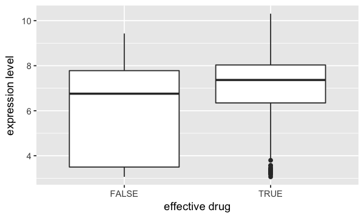

```r
# we will be focusing on drug 1014 and can choose any gene to plot
plot.dat <- data.frame(classes.1014, EXP = expr.dat[as.character(classes.1014$CL),1])

ggplot(data = plot.dat,aes(x = EFFECT, y = EXP)) +
  geom_boxplot() +
  labs(x = "effective drug", y = "expression level")
```

1. P-value histograms
   - For each gene, we will calculate the p-value when testing if the expression levels of the two groups (working vs. not working cell lines) are equal.
   - To do this, we will do 17,737 two-sample t-tests and plot their p-values.

```r
# get lists of the cell lines where the drug is effective and the drug is ineffective
effect.cl <- as.character(subset(classes.1014, EFFECT == TRUE)$CL)
ineffect.cl <- as.character(subset(classes.1014, EFFECT == FALSE)$CL)

# do a single two-sample t-test
t.test(x = expr.1014[effect.cl,1], y = expr.1014[ineffect.cl,1], var.equal = TRUE)
```

```
	Two Sample t-test

data:  expr.1014[effect.cl, 1] and expr.1014[ineffect.cl, 1]
t = 3.3348, df = 278, p-value = 0.0009698
alternative hypothesis: true difference in means is not equal to 0
95 percent confidence interval:
 0.3179253 1.2340965
sample estimates:
mean of x mean of y
 6.860047  6.084036
```

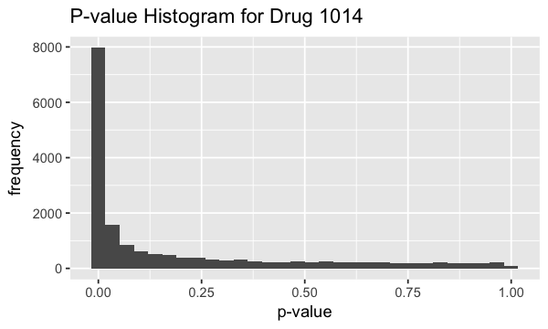

```r
# now, do all 17,737 t-tests
p.vec <- data.frame(GENE = colnames(expr.1014), P = NA)
for(i in 1:dim(p.vec)[1]){
  p.vec[i,2] <- t.test(x = expr.1014[effect.cl,i], y = expr.1014[ineffect.cl,i], var.equal = TRUE)$p.value
}

# and plot the p-values
ggplot(data = p.vec, aes(x = P)) +
  geom_histogram() +
  labs(x = "p-value", y = "frequency", title = "P-value Histogram for Drug 1014")
```

We can get the exact same p-values when using linear regression as when using a t-test.

- In this regression, we will be regressing the expression levels on the class labels (whether the drug is effective or not).

```r
p.vec2 <- data.frame(GENE = colnames(expr.1014), P = NA)
for(i in 1:dim(p.vec)[1]){
  p.vec2[i,2] <- summary(lm(expr.1014[,i] ~ classes.1014$EFFECT))$coef[2,4]
}


ggplot(data = p.vec2, aes(x = P)) +
  geom_histogram() +
  labs(x = "p-value", y = "frequency", title = "P-value Histogram for Drug 1014", subtitle = "linear regression")
```

[output not shown]